[OHI-Northeast](http://www.ohi-northeast.org/) | [OHI Science](http://ohi-science.org) | [Citation policy](http://ohi-science.org/citation-policy/)

# OHIEC: Resilience - Climate Change Pressure Prep

Compiled on Thu Aug 29 14:10:20 2019 by verstaen

# Summary

This script calculates climate change resilience values by OHINE region.

# Data

1. American Council for Energy-Efficient Economy (EEE) state and local policy rankings
2. America’s Pledge Phase 1 Report
3. US Energy Information Administration Energy Consumption Data
4. EPA CO2 Emissions from Fossil Fuel Combustion Data

**1. EEE** **Downloaded**: August, 2019

**Description**: Rankings of states’ energy efficiency policy and program efforts. https://database.aceee.org/state-scorecard-rank

**Time range**: 2006-2018

**Format**: PDF

**2. America’s Pledge** **Downloaded**: August, 2019

**Description**: Got the raw data for Figure 2-3 Climate Friendly Actions by U.S States: Types and Numbers in the America’s Pledge Report: Phase 1 (https://www.bbhub.io/dotorg/sites/28/2017/11/AmericasPledgePhaseOneReportWeb.pdf) from Tom Cyrs tom.cyrs@wri.org

**Time range**: 2006-2018

**Format**: Tabular

**3. EIA Consumption Data** **Downloaded**: August, 2019

**Description**: Energy consumption by energy source. https://www.eia.gov/beta/states/states/ny/data/dashboard/total-energy

**Time range**: 1960-2017

**Format**: Tabular

**4. EPA Carbon Emissions** **Downloaded**: August, 2019

**Description**: Carbon emissions from each state from fossil fuels. ‘https://www.epa.gov/sites/production/files/2017-09/documents/co2ffc_2015.pdf’

**Time range**: 1990-2016

**Format**: Tabular

Effectiveness: 1. Take the total CO2 emissions each year and compare to the target, which is calculated by the state set goals a. Carbon Emission Targets: Targets pulled from https://www.c2es.org/document/greenhouse-gas-emissions-targets/ Rhode Island is missing from this map so pulled from http://www.planning.ri.gov/documents/LU/energy/energy15.pdf

2. Take the percent of clean power consumption each year and compare to the target, which is calculated by the state set goals
1. Renewable/Clean Energy Targets: Drawn from http://www.ncsl.org/research/energy/renewable-portfolio-standards.aspx#me note: all targets are part os “renewable energy portfolio standards” so I won’t be including nuclear energy into calculating if states are on track for targets

```r
knitr::opts_chunk$set(fig.width = 6, fig.height = 4, fig.path = 'figs/',
                      message = FALSE, warning = FALSE)

source('~/github/ne-prep/src/R/common.R')  ### an OHINE specific version of common.R

dir_git <- '~/github/ne-prep'
dir_anx <- file.path(dir_M, 'git-annex/neprep')

library(csv)
library(tidyverse)
library(dplyr)
library(Hmisc)
library(stringi)
library(stringr)
library(readxl)
library(tabulizer)
```

Load Data

```r
eee <- read_excel(file.path(dir_anx, "_raw_data/EEE/aceee_2006_2018.xlsx"))
raw_clim_act <- read_excel(file.path(dir_anx, "_raw_data/Americas_Pledge/states_climate_regs_summary.xlsx"), skip=2, sheet = 2)
```

**Regulations** Energy Efficiency Scores

```r
#calculate
eee_score <- eee %>%
  mutate(score_eee = score/target)

#save
write.csv(eee_score, file = "data/eee_score")
```

Visualize

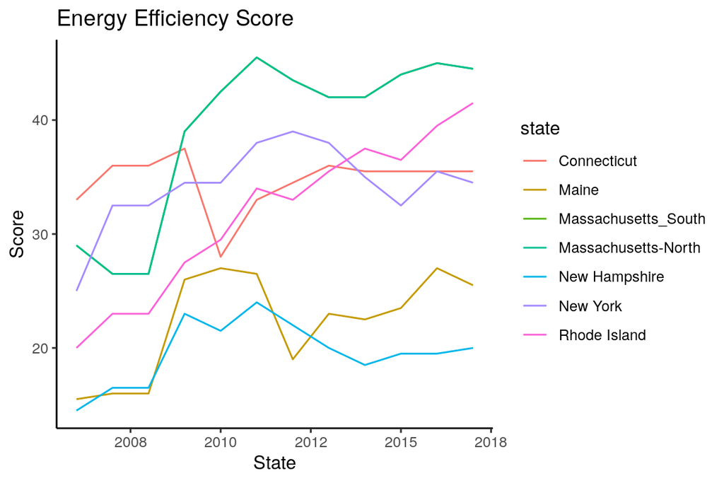

```r
eee_score_graph <-ggplot(eee_score)+
  geom_line(aes(x=year, y = score, color=state))+
  ggtitle("Energy Efficiency Score") +
  ylab("Score") +
  xlab("State") +
  theme_classic()
eee_score_graph
```

```r
ggsave("figs/eee_score_graph.jpg", width=7, height=5, dpi=300)
```

1. Integrating transportation & land-use in comprehensive plans
2. Dedicated funding streams for public transit
3. Adopting legislation in line with Complete Streets objectives
4. Financial incentives for high efficiency vehicles
5. Conservation easement tax credits
6. California’s vehicle emission standards
7. Rules and incentives to reduce food waste
8. Most recent building energy codes
9. Appliance and equipment energy efficiency standards
10. Carbon pricing
11. Zero Emission Vehicle mandate
12. Cost-sharing programs to improve forest systems
13. Wildfire protection incentives
14. Coal mine methane standards
15. Low carbon fuel standard
16. Methane standards for existing oil and natural gas facilities
17. Setting methane emission reduction targets
18. Freight-specific energy efficiency performance metrics
19. HFC management program requiring all leaks to be repaired
20. Financial incentives for CCS
21. Zero-emission credits for nuclear
22. GHG Emission Targets
23. Renewable energy portfolio standards or goals
24. Property Assessed Clean Energy
25. Combined heat and power financing and incentives
26. Landfill gas energy project bond, grant, loan, or rebate programs
27. Energy efficiency resource standard or goals
28. Property tax programs to support sustainable forests
29. Efficient vehicle requirement for public fleet procurement
30. Freight plan with multimodal freight strategies

```r
clim_act <- raw_clim_act %>%
  filter(State == "Maine" | State == "Massachusetts" | State == "New Hampshire" | State == "Rhode Island" | State == "Connecticut" | State == "New York" | State == "Total # of actions considered") %>%
  select(-"Energy efficiency", -"Total") %>%
  mutate(target = 23,
         total = rowSums(.[2:9]),
         score = total/target) %>%
  uncount(13, .id = "n", .remove = F) %>%
  mutate(year = ifelse(n == 1, 2005, n + 2004)) %>%
  select(-n) %>%
  filter(State != "Total # of actions considered")

write.csv(clim_act, file = "data/clim_act")
```

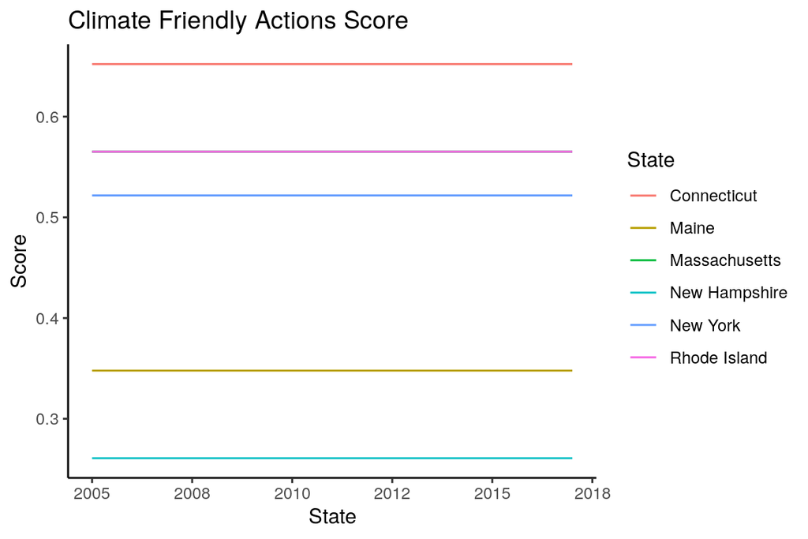

```r
clim_act_graph <-ggplot(clim_act)+
  geom_line(aes(x=year, y = score, color=State))+
  ggtitle("Climate Friendly Actions Score") +
  ylab("Score") +
  xlab("State") +
  theme_classic()
clim_act_graph
```

```r
ggsave("figs/clim_act_graph.jpg", width=7, height=5, dpi=300)
```

**Effectivness**

##Clean Energy Cosumption

1. Maine = 40% by 2017
2. New Hampshire = 25.2% by 2025
3. Connecticut = 44% by 2030
4. Massachusetts = 35% 2030
5. New York = 50% by 2030
6. Rhode Island = 38.5% by 2035

Load in the energy consumption data for each state. All numbers are in Billion Btu

```r
ct_con_raw <- read_csv(file.path(dir_anx, "_raw_data/EIA/energy_consumption/ct_consumption.csv"), skip = 1)
me_con_raw <- read_csv(file.path(dir_anx, "_raw_data/EIA/energy_consumption/me_consumption.csv"), skip = 1)
ma_con_raw <- read_csv(file.path(dir_anx, "_raw_data/EIA/energy_consumption/ma_consumption.csv"), skip = 1)
ri_con_raw <- read_csv(file.path(dir_anx, "_raw_data/EIA/energy_consumption/ri_consumption.csv"), skip = 1)
nh_con_raw <- read_csv(file.path(dir_anx, "_raw_data/EIA/energy_consumption/nh_consumption.csv"), skip = 1)
ny_con_raw <- read_csv(file.path(dir_anx, "_raw_data/EIA/energy_consumption/ny_consumption.csv"), skip = 1)
```

Connecticut

```r
ct_con <- ct_con_raw %>%
  select(-"Series Name_1",-"Series Name_2",-"Series Name_3",-"Series Name_4",-"Series Name_5",-"Series Name_6") %>%
  rename(year = "Series Name",
         coal = "Coal total consumption, Connecticut",
         nat_gas = "Natural gas total consumption (excluding supplemental gaseous fuels), Connecticut",
         nuc = "Nuclear energy consumed for electricity generation, total, Connecticut",
         petrol = "All petroleum products total consumption, excluding fuel ethanol blended into motor gasoline, Connecticut",
         renew = "Renewable energy total consumption, Connecticut",
         net_elec_flow = "Net interstate flow of electricity and associated losses (negative indicates flow out of state), Connecticut",
         net_elec_import = "Net imports of electricity into the United States, Connecticut") %>%
  mutate(state = "Connecticut") %>%
  filter(year <= "2017") %>%
  select(-net_elec_flow, -net_elec_import)
```

Maine

```r
me_con <- me_con_raw %>%
  select(-"Series Name_1",-"Series Name_2",-"Series Name_3",-"Series Name_4",-"Series Name_5",-"Series Name_6") %>%
  rename(year = "Series Name",
         coal = "Coal total consumption, Maine",
         nat_gas = "Natural gas total consumption (excluding supplemental gaseous fuels), Maine",
         nuc = "Nuclear energy consumed for electricity generation, total, Maine",
         petrol = "All petroleum products total consumption, excluding fuel ethanol blended into motor gasoline, Maine",
         renew = "Renewable energy total consumption, Maine",
         net_elec_flow = "Net interstate flow of electricity and associated losses (negative indicates flow out of state), Maine",
         net_elec_import = "Net imports of electricity into the United States, Maine") %>%
  mutate(state = "Maine") %>%
  filter(year <= "2017") %>%
  select(-net_elec_flow, -net_elec_import)
```

Massachusetts

```r
ma_con <- ma_con_raw %>%
  select(-"Series Name_1",-"Series Name_2",-"Series Name_3",-"Series Name_4",-"Series Name_5",-"Series Name_6") %>%
  rename(year = "Series Name",
         coal = "Coal total consumption, Massachusetts",
         nat_gas = "Natural gas total consumption (excluding supplemental gaseous fuels), Massachusetts",
         nuc = "Nuclear energy consumed for electricity generation, total, Massachusetts",
         petrol = "All petroleum products total consumption, excluding fuel ethanol blended into motor gasoline, Massachusetts",
         renew = "Renewable energy total consumption, Massachusetts",
         net_elec_flow = "Net interstate flow of electricity and associated losses (negative indicates flow out of state), Massachusetts",
         net_elec_import = "Net imports of electricity into the United States, Massachusetts") %>%
  mutate(state = "Massachusetts") %>%
  filter(year <= "2017") %>%
  select(-net_elec_flow, -net_elec_import)
```

Rhode Island

```r
ri_con <- ri_con_raw %>%
  select(-"Series Name_1",-"Series Name_2",-"Series Name_3",-"Series Name_4",-"Series Name_5",-"Series Name_6") %>%
  rename(year = "Series Name",
         coal = "Coal total consumption, Rhode Island",
         nat_gas = "Natural gas total consumption (excluding supplemental gaseous fuels), Rhode Island",
         nuc = "Nuclear energy consumed for electricity generation, total, Rhode Island",
         petrol = "All petroleum products total consumption, excluding fuel ethanol blended into motor gasoline, Rhode Island",
         renew = "Renewable energy total consumption, Rhode Island",
         net_elec_flow = "Net interstate flow of electricity and associated losses (negative indicates flow out of state), Rhode Island",
         net_elec_import = "Net imports of electricity into the United States, Rhode Island") %>%
  mutate(state = "Rhode Island") %>%
  filter(year <= "2017") %>%
  select(-net_elec_flow, -net_elec_import)
```

New Hampshire

```r
nh_con <- nh_con_raw %>%
  select(-"Series Name_1",-"Series Name_2",-"Series Name_3",-"Series Name_4",-"Series Name_5",-"Series Name_6") %>%
  rename(year = "Series Name",
         coal = "Coal total consumption, New Hampshire",
         nat_gas = "Natural gas total consumption (excluding supplemental gaseous fuels), New Hampshire",
         nuc = "Nuclear energy consumed for electricity generation, total, New Hampshire",
         petrol = "All petroleum products total consumption, excluding fuel ethanol blended into motor gasoline, New Hampshire",
         renew = "Renewable energy total consumption, New Hampshire",
         net_elec_flow = "Net interstate flow of electricity and associated losses (negative indicates flow out of state), New Hampshire",
         net_elec_import = "Net imports of electricity into the United States, New Hampshire") %>%
  mutate(state = "New Hampshire") %>%
  filter(year <= "2017") %>%
  select(-net_elec_flow, -net_elec_import)
```

New York

```r
ny_con <- ny_con_raw %>%
  select(-"Series Name_1",-"Series Name_2",-"Series Name_3",-"Series Name_4",-"Series Name_5",-"Series Name_6") %>%
  rename(year = "Series Name",
         coal = "Coal total consumption, New York",
         nat_gas = "Natural gas total consumption (excluding supplemental gaseous fuels), New York",
         nuc = "Nuclear energy consumed for electricity generation, total, New York",
         petrol = "All petroleum products total consumption, excluding fuel ethanol blended into motor gasoline, New York",
         renew = "Renewable energy total consumption, New York",
         net_elec_flow = "Net interstate flow of electricity and associated losses (negative indicates flow out of state), New York",
         net_elec_import = "Net imports of electricity into the United States, New York") %>%
  mutate(state = "New York") %>%
  filter(year <= "2017") %>%
  select(-net_elec_flow, -net_elec_import)
```

Combine all states energy consumption data into one and calculate the percent of renewable. Also calculating percent with clean(ie: nuclear) for fun/its interesting

```r
consum <- rbind(me_con, ma_con, ct_con, nh_con, ny_con, ri_con) %>%
  mutate(coal = as.numeric(coal),
         nat_gas = as.numeric(nat_gas),
         nuc = as.numeric(nuc),
         petrol = as.numeric(petrol),
         renew = as.numeric(renew)) %>%
  rowwise() %>%
  mutate(total = sum(coal, nat_gas, nuc, petrol, renew),
         non_renew = sum(coal, nat_gas, nuc, petrol),
         per_renew = renew/total,
         year = as.numeric(year),
         clean = sum(nuc, renew),
         per_clean= clean/total) %>%
  ungroup()
```

Visualize

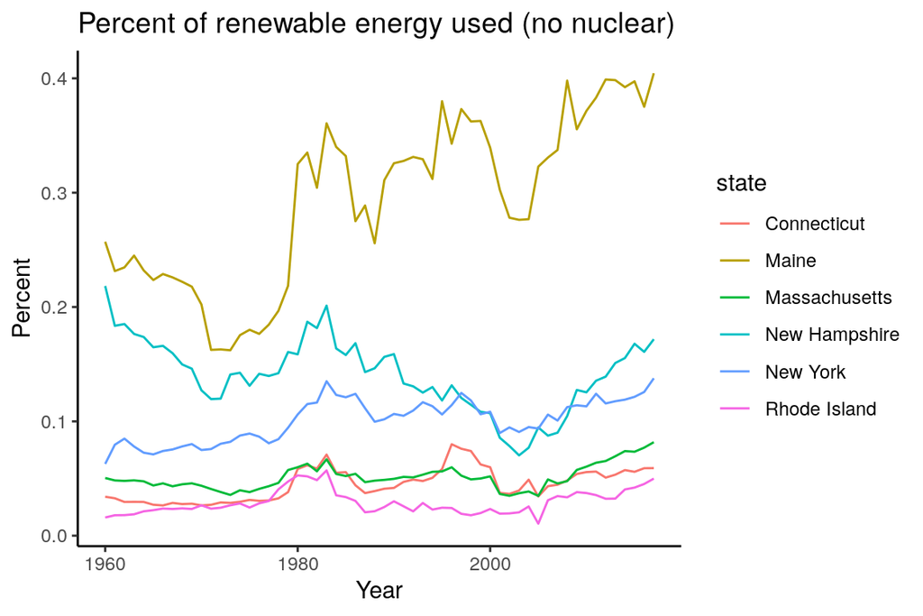

```r
# renewable only
con_renew_graph <- ggplot(consum)+
  geom_line(aes(x=year, y= per_renew, color= state))+
 ggtitle("Percent of renewable energy used (no nuclear)") +
  ylab("Percent") +
  xlab("Year") +
  theme_classic()

con_renew_graph
```

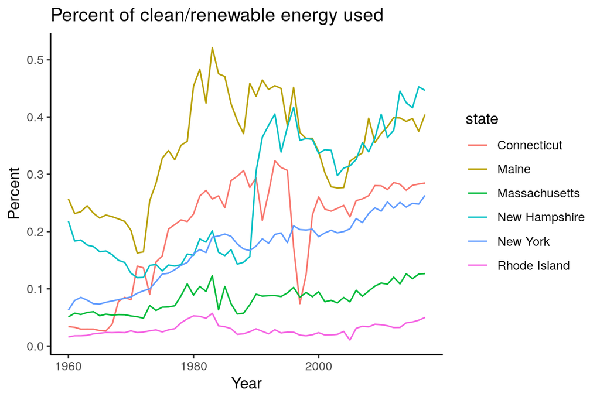

```r
#clean(nuclear) and renewable
con_clean_graph <- ggplot(consum)+
  geom_line(aes(x=year, y= per_clean, color= state))+
 ggtitle("Percent of clean/renewable energy used") +
  ylab("Percent") +
  xlab("Year") +
  theme_classic()

con_clean_graph
```

Now that we have the actual percentage of energy consumption that comes from renewable, we can do linear regressions using the state set targets as the end points. With this we can calculate if each state is on track to hitting their renewable energy target goal for a given year.

Maine

```r
#MA 40% clean by 2017
me <- consum %>%
  filter(year >= 2004 & year <= 2017) %>%
  arrange(year) %>%
  filter(state == "Maine") %>%
  mutate(year_n = seq(1:14))

#create tibble with the start (value in 2005) and end (goal in whichever year) to do a linear regression
me_target <- tribble(
  ~year, ~per_clean,
  1, 0.277,
  14, 0.4
)

#super simple regression for equation to calculate the necessary percent clean emmisions each year to reach target
lm_me <- lm(per_clean ~ year, data = me_target)
#intercept = 0.26754 ; coef = 0.00946
summary(lm_me)
```

```
##
## Call:
## lm(formula = per_clean ~ year, data = me_target)
##
## Residuals:
## ALL 2 residuals are 0: no residual degrees of freedom!
##
## Coefficients:
##             Estimate Std. Error t value Pr(>|t|)
## (Intercept)  0.26754         NA      NA       NA
## year         0.00946         NA      NA       NA
##
## Residual standard error: NaN on 0 degrees of freedom
## Multiple R-squared:     1,   Adjusted R-squared:   NaN
## F-statistic:  NaN on 1 and 0 DF,  p-value: NA
```

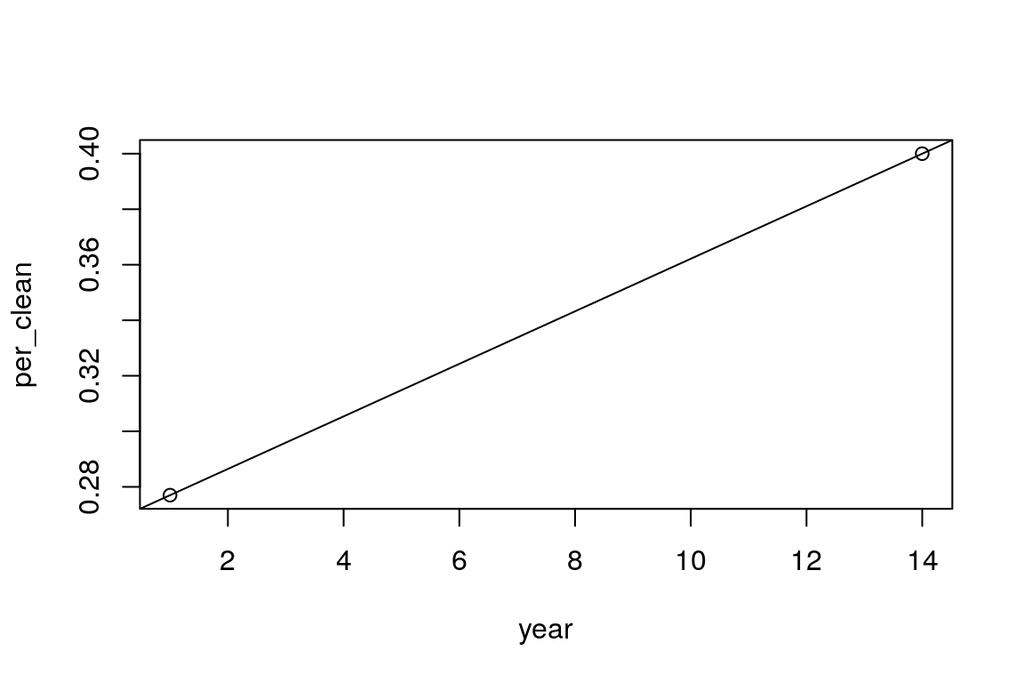

```r
plot(per_clean ~ year, data = me_target)
abline(lm_me)
```

```r
###trying to use equation no loop
me_clean_target <- me %>%
  rowwise() %>%
  mutate(target = (0.00946*year_n + 0.26754 ),
         per_clean = round(per_clean, digits= 2),
         target = round(target, digits= 2)) %>%
  filter( year != "2004") %>%
  select(year, state, per_renew, target)
```

Massachusetts

```r
#MA 35% clean by 2030
ma <- consum %>%
  filter(year >= 2004 & year <= 2017) %>%
  arrange(year) %>%
  filter(state == "Massachusetts")  %>%
  mutate(year_n = seq(1:14))

#create tibble with the start (value in 2005) and end (goal in whichever year) to do a linear regression
ma_target <- tribble(
  ~year, ~per_clean,
  1,        0.0387  ,
  26, .35)

#super simple regression for equation to calculate the necessary percent clean emmisions each year to reach target
lm_ma <- lm(per_clean ~ year, data = ma_target)
#coef = 0.0125    ; int = 0.0262

ma_clean_target <- ma %>%
  rowwise() %>%
  mutate(target = (0.0125*year_n+ 0.0262   ),
         per_clean = round(per_clean, digits= 2),
         target = round(target, digits= 2)) %>%
  filter( year != "2004") %>%
  select(year, state, per_renew, target)
```

New Hampshire

```r
#NH 25.2% clean by 2025
nh <- consum %>%
  filter(year >= 2004 & year <= 2017) %>%
  arrange(year) %>%
  filter(state == "New Hampshire") %>%
  mutate(year_n = seq(1:14))

#create tibble with the start (value in 2005) and end (goal in whichever year) to do a linear regression
nh_target <- tribble(
  ~year, ~per_clean,
  1, 0.0770,
  21, .252
)

#super simple regression for equation to calculate the necessary percent clean emmisions each year to reach target
lm_nh <- lm(per_clean ~ year, data = nh_target)
#coef=  0.00875 int=  0.06825

nh_clean_target <- nh %>%
  mutate(target = ( 0.00875    *year_n + 0.06825 ),
         per_clean = round(per_clean, digits= 2),
         target = round(target, digits= 2)) %>%
   filter( year != "2004") %>%
  select(year, state, per_renew, target)
```

Rhode Island

```r
#RI 38.5% clean by 2035
ri <- consum %>%
  filter(year >= 2004 & year <= 2017) %>%
  arrange(year) %>%
  filter(state == "Rhode Island") %>%
  mutate(year_n = seq(1:14))

#create tibble with the start (value in 2005) and end (goal in whichever year) to do a linear regression
ri_target <- tribble(
  ~year, ~per_clean,
  0, 0.0256 ,
  31, .385)

#super simple regression for equation to calculate the necessary percent clean emmisions each year to reach target
lm_ri <- lm(per_clean ~ year, data = ri_target)
#coef=0.0256  , int = 0.0116

ri_clean_target <- ri %>%
   mutate(target = ( 0.0116  *year_n+0.0256),
         per_clean = round(per_clean, digits= 2),
         target = round(target, digits= 2)) %>%
  filter(year != "2004") %>%
  select(year, state, per_renew, target)
```

New York

```r
#NY 50% clean by 2030
ny <- consum %>%
  filter(year >= 2004 & year <= 2017) %>%
  arrange(year) %>%
  filter(state == "New York") %>%
  mutate(year_n = seq(1:14))

#create tibble with the start (value in 2005) and end (goal in whichever year) to do a linear regression
ny_target <- tribble(
  ~year, ~per_clean,
  0,    0.0950  ,
  26, .50)

#super simple regression for equation to calculate the necessary percent clean emmisions each year to reach target
lm_ny <- lm(per_clean ~ year, data = ny_target)
#coef=0.0156   , int =   0.0950

ny_clean_target <- ny %>%
  mutate(target = (0.0156*year_n +0.0950 ),
         per_clean = round(per_clean, digits= 2),
         target = round(target, digits= 2)) %>%
  filter(year != "2004") %>%
  select(year, state, per_renew, target)
```

Connecticut

```r
#CT 44% clean by 2030
ct <- consum %>%
  filter(year >= 2004 & year <= 2017) %>%
  arrange(year) %>%
  filter(state == "Connecticut")  %>%
  mutate(year_n = seq(1:14))

#create tibble with the start (value in 2005) and end (goal in whichever year) to do a linear regression
ct_target <- tribble(
  ~year, ~per_clean,
  0, 0.0490,
  26, .44
)

#super simple regression for equation to calculate the necessary percent clean emmisions each year to reach target
lm_ct <- lm(per_clean ~ year, data = ct_target)
#coef= 0.015  , int= 0.049

ct_clean_target <- ct %>%
  mutate(target = (0.015*year_n + 0.049 ),
         per_clean = round(per_clean, digits= 2),
         target = round(target, digits= 2)) %>%
  filter(year != "2004") %>%
  select(year, state, per_renew, target)
```

Combine all states df with target

```r
energy_target <- rbind(me_clean_target, nh_clean_target, ma_clean_target, ri_clean_target, ct_clean_target, ny_clean_target)
```

Calculate scores

```r
energy_consump_scores <- energy_target %>%
  mutate(score = per_renew/target,
         score = if_else(score >1, 1, score))
#save
write.csv(energy_consump_scores, file = "data/power_gen_scores_nuc")
```

Visualize scores

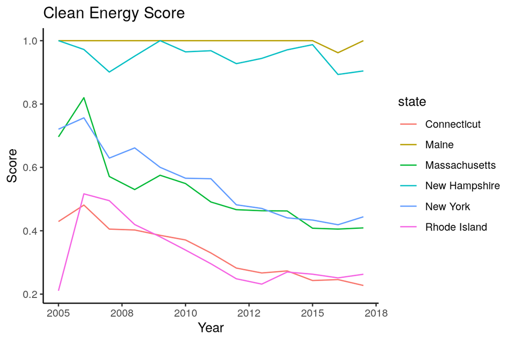

```r
graph_clean_energy_score_nuc <-ggplot(energy_consump_scores)+
  geom_line(aes(x=year, y = score, color=state))+
  ggtitle("Clean Energy Score") +
  ylab("Score") +
  xlab("Year") +
  theme_classic()
graph_clean_energy_score_nuc
```

```r
ggsave("figs/graph_clean_energy_score.jpg", width=7, height=5, dpi=300)
```

##Carbon Emmissions Targets: Maine= 80% reduction below 1990 levels by 2050 New Hampshire= 80% reduction below 1990 levels by 2050 Connecticut= 80% reduction below 2001 levels by 2050 Massachusetts= 80% reduction below 1990 levels by 2050 New York= 100% reduction below 1990 levels by 2050 Rhode Island= 80% reduction below 1990 levels by 2050

Converting table from a pdf to a df

```r
location <- file.path(dir_anx, "_raw_data/EPA/co2_emmissions_EPA.pdf")
out <- extract_tables(location)

#page 1
out1 <- out[[1]] %>%
  as.data.frame() %>%
  rename(state = V1, blank = V2, "1990" = V3, "1991"= V4, "1992"= V5, "1993"=V6, "1994"=V7, "1995"=V8, "1996"=V9, "1997"=V10, "1998"=V11, "1999"=V12, "2000"=V13, "2001"=V14, "2002"=V15, "2003"=V16, "2004"=V17, "2005"=V18, "2006"=V19, "2007"=V20, "2008"=V21, "2009"=V22, "2010"=V23, "2011"=V24, "2012"=V25, "2013"=V26, "2014"=V27, "2015"=V28, "2016"=V29) %>%
  filter(state != "State Sector",
         state != "Commercial",
         state != "Industrial",
         state != "Residential",
         state != "Transportation",
         state != "Electric Power") %>%
  select(-blank)

#page 2
out2 <- out[[2]] %>%
  as.data.frame() %>%
  rename(state = V1, blank = V2, "1990" = V3, "1991"= V4, "1992"= V5, "1993"=V6, "1994"=V7, "1995"=V8, "1996"=V9, "1997"=V10, "1998"=V11, "1999"=V12, "2000"=V13, "2001"=V14, "2002"=V15, "2003"=V16, "2004"=V17, "2005"=V18, "2006"=V19, "2007"=V20, "2008"=V21, "2009"=V22, "2010"=V23, "2011"=V24, "2012"=V25, "2013"=V26, "2014"=V27, "2015"=V28, "2016"=V29) %>%
  filter(blank != "Commercial",
         blank != "Industrial",
         blank != "Residential",
         blank != "Transportation",
         blank != "Electric Power")%>%
  select(-blank)

#page 3
out3 <- out[[3]] %>%
   as.data.frame() %>%
  rename(state = V1, "1990" = V2, "1991"= V3, "1992"= V4, "1993"=V5, "1994"=V6, "1995"=V7, "1996"=V8, "1997"=V9, "1998"=V10, "1999"=V11, "2000"=V12, "2001"=V13, "2002"=V14, "2003"=V15, "2004"=V16, "2005"=V17, "2006"=V18, "2007"=V19, "2008"=V20, "2009"=V21, "2010"=V22, "2011"=V23, "2012"=V24, "2013"=V25, "2014"=V26, "2015"=V27, "2016"=V28) %>%
  filter(state != "Commercial",
         state != "Industrial",
         state != "Residential",
         state != "Transportation",
         state != "Electric Power")

#page 4
out4 <- out[[4]] %>%
   as.data.frame() %>%
  rename(state = V1, "1990" = V2, "1991"= V3, "1992"= V4, "1993"=V5, "1994"=V6, "1995"=V7, "1996"=V8, "1997"=V9, "1998"=V10, "1999"=V11, "2000"=V12, "2001"=V13, "2002"=V14, "2003"=V15, "2004"=V16, "2005"=V17, "2006"=V18, "2007"=V19, "2008"=V20, "2009"=V21, "2010"=V22, "2011"=V23, "2012"=V24, "2013"=V25, "2014"=V26, "2015"=V27, "2016"=V28) %>%
  filter(state != "Commercial",
         state != "Industrial",
         state != "Residential",
         state != "Transportation",
         state != "Electric Power")

#page 5
out5 <- out[[5]] %>%
     as.data.frame() %>%
  rename(state = V1, "1990" = V2, "1991"= V3, "1992"= V4, "1993"=V5, "1994"=V6, "1995"=V7, "1996"=V8, "1997"=V9, "1998"=V10, "1999"=V11, "2000"=V12, "2001"=V13, "2002"=V14, "2003"=V15, "2004"=V16, "2005"=V17, "2006"=V18, "2007"=V19, "2008"=V20, "2009"=V21, "2010"=V22, "2011"=V23, "2012"=V24, "2013"=V25, "2014"=V26, "2015"=V27, "2016"=V28) %>%
  filter(state != "Commercial",
         state != "Industrial",
         state != "Residential",
         state != "Transportation",
         state != "Electric Power")
```

Combining and Tidying

```r
emissions <- rbind(out1, out2, out3, out4, out5) %>%
  gather(year, emission, 2:28) %>%
   filter(state == "Maine" | state == "New Hampshire" | state == "Massachusetts" | state == "New Hampshire" | state == "Rhode Island" | state == "Connecticut" | state == "New York") %>%
  mutate(year = as.numeric(year),
         emission = as.numeric(emission)) %>%
  mutate(end_target = case_when(state == "Maine" ~ (23.64 - 0.8*(23.64)),
                            state == "New Hampshire" ~ (14.59 - 0.8*(14.59)),
                            state == "Connecticut" ~ (41.53 - 0.8*(41.53)),
                            state == "Massachusetts" ~ (83.09 - 0.8*(83.09)),
                            state == "New York" ~ (207.82 - 1*(207.82)),
                            state == "Rhode Island" ~ (8.91 - 0.8*(8.91))))

#save
write.csv(emissions, file = "data/emissions")
```

Visualize emmissions

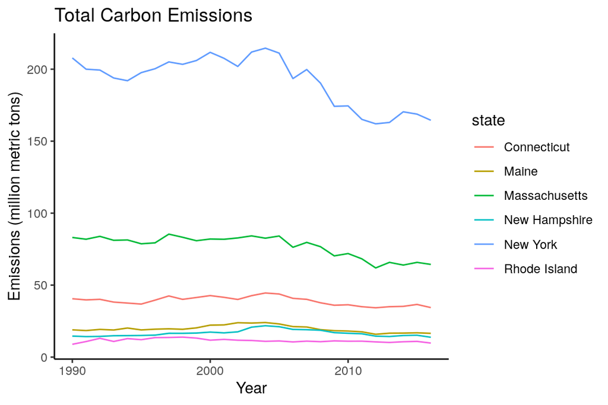

```r
graph_em <-ggplot(emissions)+
  geom_line(aes(x=year, y = emission, color=state))+
  ggtitle("Total Carbon Emissions") +
  ylab("Emissions (million metric tons)") +
  xlab("Year") +
  theme_classic()

graph_em
```

```r
ggsave("figs/graph_em .jpg", width=7, height=5, dpi=300)
```

Regressions for trend targets

New Hampshire

```r
#NH 80% reduction below 1990 levels by 2050
nh_em <- emissions %>%
  filter(state == "New Hampshire") %>%
  filter(year >= 2004 & year <= 2017) %>%
  mutate(year_n = seq(1:13))

#create tibble with the start (value in 2005) and end (goal in whichever year) to do a linear regression
nh_em_target <- tribble(
  ~year, ~emission,
  1,    21.8    ,
  46, 2.92)

#super simple regression for equation to calculate the necessary percent clean emmisions each year to reach target
lm_nh_em <- lm(emission~ year, data = nh_em_target)
#coe =   -0.42   ; int= 22.22

nh_em_target <- nh_em %>%
  mutate(target = (  -0.42  *year_n +22.22),
         emission = round(emission, digits= 2),
         target = round(target, digits= 2)) %>%
  filter(year != "2004") %>%
  select(year, state, emission, target)
```

Massachusetts

```r
#MA 80% reduction below 1990 levels by 2050
ma_em <- emissions %>%
  filter(state == "Massachusetts") %>%
  filter(year >= 2004 & year <= 2017)%>%
  mutate(year_n = seq(1:13))

#create tibble with the start (value in 2005) and end (goal in whichever year) to do a linear regression
ma_em_target <- tribble(
  ~year, ~emission,
  1, 82.6   ,
  46, 16.6)

#super simple regression for equation to calculate the necessary percent clean emmisions each year to reach target
lm_ma_em <- lm(emission~ year, data = ma_em_target)
#coe=--1.47   ; int =  84.07

ma_em_target <- ma_em %>%
  mutate(target = (-1.47*year_n +  84.07  ),
         emission = round(emission, digits= 2),
         target = round(target, digits= 2)) %>%
  filter(year != "2004") %>%
  select(year, state, emission, target)
```

Rhode Island

```r
#RI 80% reduction below 1990 levels by 2050
ri_em <- emissions %>%
  filter(state == "Rhode Island") %>%
  filter(year >= 2004 & year <= 2017)%>%
  mutate(year_n = seq(1:13))

#create tibble with the start (value in 2005) and end (goal in whichever year) to do a linear regression
ri_em_target <- tribble(
  ~year, ~emission,
  1, 10.97,
  46, 1.78
)

#super simple regression for equation to calculate the necessary percent clean emmisions each year to reach target
lm_ri_em <- lm(emission~ year, data = ri_em_target)
#coe= -0.204  ; int = 11.174

ri_em_target<- ri_em %>%
    mutate(target = (-0.204 *year_n+11.174 ),
         emission = round(emission, digits= 2),
         target = round(target, digits= 2)) %>%
  filter(year != "2004") %>%
  select(year, state, emission, target)
```

Connecticut

```r
#CT 80% reduction below 2001 levels by 2050
ct_em <- emissions %>%
  filter(state == "Connecticut") %>%
  filter(year >= 2004 & year <= 2017)%>%
  mutate(year_n = seq(1:13))

#create tibble with the start (value in 2005) and end (goal in whichever year) to do a linear regression
ct_em_target <- tribble(
  ~year, ~emission,
  1, 44.5   ,
  46, 8.31)

#super simple regression for equation to calculate the necessary percent clean emmisions each year to reach target
lm_ct_em <- lm(emission~ year, data = ct_em_target)
#coef=-0.804 ; int = 45.304

ct_em_target <- ct_em %>%
  mutate(target = (-0.804 *year_n+45.304),
         emission = round(emission, digits= 2),
         target = round(target, digits= 2)) %>%
  filter(year != "2004") %>%
  select(year, state, emission, target)
```

New York

```r
#NY 100% reduction below 1990 levels by 2050
ny_em <- emissions %>%
  filter(state == "New York") %>%
  filter(year >= 2004 & year <= 2017) %>%
  mutate(year_n = seq(1:13))

#create tibble with the start (value in 2005) and end (goal in whichever year) to do a linear regression
ny_em_target <- tribble(
  ~year, ~emission,
  1, 215,
  46, 0)

#super simple regression for equation to calculate the necessary percent clean emmisions each year to reach target
lm_ny_em <- lm(emission~ year, data = ny_em_target)
#coe= -4.78  ; int = 215.00

ny_em_target <- ny_em %>%
  mutate(target = (-4.78  *year_n+219.78),
         emission = round(emission, digits= 2),
         target = round(target, digits= 2)) %>%
  filter(year != "2004") %>%
  select(year, state, emission, target)
```

Maine

```r
#MA 80% reduction below 1990 levels by 2050
me_em <- emissions %>%
  filter(state == "Maine") %>%
  filter(year >= 2004 & year <= 2017) %>%
  mutate(year_n = seq(1:13))

#create tibble with the start (value in 2005) and end (goal in whichever year) to do a linear regression
me_em_target <- tribble(
  ~year, ~emission,
  1, 24.0,
  46, 4.73)

#super simple regression for equation to calculate the necessary percent clean emmisions each year to reach target
lm_me_em <- lm(emission~ year, data = me_em_target)
#coe= -0.428; int = 24.428

me_em_target <- me_em %>%
  mutate(target = (-0.428*year_n+24.428),
         emission = round(emission, digits= 2),
         target = round(target, digits= 2)) %>%
  filter(year != "2004") %>%
  select(year, state, emission, target)
```

Combine all states df with target

```r
emissions_target <- rbind(nh_em_target, ma_em_target, ri_em_target, ct_em_target, ny_em_target, me_em_target)
```

Calculate scores

```r
emissions_scores <- emissions_target %>%
  mutate(score = target/emission,
         score = if_else(score >1, 1, score))
#save
write.csv(emissions_scores, file = "data/emissions_scores")
```

Visualize scores

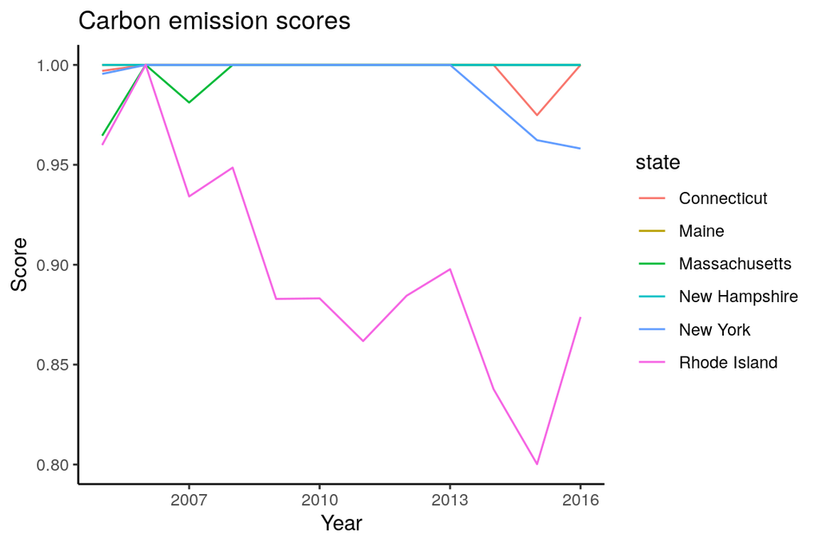

```r
graph_emissions_scores <-ggplot(emissions_scores)+
  geom_line(aes(x=year, y = score, color=state))+
  ggtitle("Carbon emission scores") +
  ylab("Score") +
  xlab("Year") +
  theme_classic()
graph_emissions_scores
```

```r
ggsave("figs/graph_emissions_scores.jpg", width=7, height=5, dpi=300)
```

Calculate Climate Change Resilience Score

Tidy each piece so can combine

```r
##eee scores
eee_score_t <- eee_score %>%
  mutate(state = str_to_title(gsub(",", " ", state)),
         rgn_id1 = case_when(state == "Maine" ~ 6,
                            state == "New Hampshire" ~ 9,
                            state == "Massachusetts" ~ 7,
                            state == "Rhode Island" ~ 11,
                            state == "Connecticut" ~ 5,
                            state == "New York" ~ 10),
         rgn_id8 = case_when(state == "Massachusetts" ~ 8)) %>%
  rename(rgn_name = state) %>%
  replace(., is.na(.), "0") %>%
  gather(rgn_id1, rgn_id8, key= "filler", value = "rgn_id") %>%
  filter(rgn_id != "0") %>%
  select(year, rgn_name, rgn_id, score) %>%
  rename(score_eee = score) %>%
  mutate(rgn_name = ifelse(rgn_name == "Massachusetts" & rgn_id == 7, "Massachusetts-North",
                           ifelse(rgn_name == "Massachusetts" & rgn_id == 8, "Massachusetts-South", rgn_name)))

##emmissions scores
#create a seperate df to bind to the main one for year 2017 beacuse no data for that
em_2017<- tribble(
  ~year, ~rgn_name, ~rgn_id,
  2017, "Maine", 6,
  2017, "New Hampshire", 9,
  2017, "Massachusetts-North", 7,
  2017, "Rhode Island", 11,
  2017, "Connecticut", 5,
  2017, "New York", 10,
  2017, "Massachusetts-South", 8
  ) %>%
  as.data.frame() %>%
  add_column(score= NA)

emissions_scores_t <- emissions_scores %>%
  mutate(rgn_id1 = case_when(state == "Maine" ~ 6,
                            state == "New Hampshire" ~ 9,
                            state == "Massachusetts" ~ 7,
                            state == "Rhode Island" ~ 11,
                            state == "Connecticut" ~ 5,
                            state == "New York" ~ 10),
         rgn_id8 = case_when(state == "Massachusetts" ~ 8)) %>%
  rename(rgn_name = state) %>%
  replace(., is.na(.), "0") %>%
  gather(rgn_id1, rgn_id8, key= "filler", value = "rgn_id") %>%
  filter(rgn_id != "0") %>%
  select(year, rgn_name, rgn_id, score) %>%
  mutate(rgn_name = ifelse(rgn_id == 1, "Offshore",
                       ifelse(rgn_id==2, "Georges Bank",
                               ifelse(rgn_id==3, "Gulf of Maine",
                                      ifelse(rgn_id==4, "Mid-Atlantic Bight",
                                             ifelse(rgn_id==5, "Connecticut",
                                                    ifelse(rgn_id==6, "Maine",
                                                           ifelse(rgn_id==7, "Massachusetts-North",
                                                                  ifelse(rgn_id==8, "Massachusetts-South",
                                                                         ifelse(rgn_id==9, "New Hampshire",
                                                                                ifelse(rgn_id==10, "New York",
                                                                                       "Rhode Island")))))))))))%>%
  rbind(em_2017) %>%
  arrange(rgn_name) %>%
  fill(score, .direction = "down") %>%
  rename(score_em = score)

##power consumption scores
energy_consump_scores_t <- energy_consump_scores %>%
  mutate(rgn_id1 = case_when(
    state == "Maine" ~ "6",
    state == "New Hampshire" ~ "9",
    state == "Massachusetts" ~ "7",
    state == "Rhode Island" ~ "11",
    state == "Connecticut" ~ "5",
    state == "New York" ~ "10"),
    rgn_id2 = case_when(
    state == "Massachusetts" ~ "8"
    )) %>%
  replace(., is.na(.), "0") %>%
  gather(rgn_id1, rgn_id2, key= "filler", value = "rgn_id") %>%
  filter(rgn_id != "0") %>%
  rename(rgn_name = "state") %>%
  select(-filler) %>%
  select(year, rgn_name, rgn_id, score) %>%
  mutate(rgn_name = ifelse(rgn_name == "Massachusetts" & rgn_id == 7, "Massachusetts-North",
                           ifelse(rgn_name == "Massachusetts" & rgn_id == 8, "Massachusetts-South", rgn_name))) %>%
  rename(score_power = score)

##climate actions scores
clim_act_t <- clim_act %>%
  select(year, State, score) %>%
  rename(state=State) %>%
  mutate(rgn_id1 = case_when(state == "Maine" ~ 6,
                            state == "New Hampshire" ~ 9,
                            state == "Massachusetts" ~ 7,
                            state == "Rhode Island" ~ 11,
                            state == "Connecticut" ~ 5,
                            state == "New York" ~ 10),
         rgn_id8 = case_when(state == "Massachusetts" ~ 8)) %>%
  rename(rgn_name = state) %>%
  replace(., is.na(.), "0") %>%
  gather(rgn_id1, rgn_id8, key= "filler", value = "rgn_id") %>%
  filter(rgn_id != "0") %>%
  select(year, rgn_name, rgn_id, score) %>%
   mutate(rgn_name = ifelse(rgn_name == "Massachusetts" & rgn_id == 7, "Massachusetts-North",
                           ifelse(rgn_name == "Massachusetts" & rgn_id == 8, "Massachusetts-South", rgn_name))) %>%
  rename(score_act = score)
```

Combine all scores!

```r
cc_res_score <- left_join(emissions_scores_t, clim_act_t, by = c("year", "rgn_name", "rgn_id")) %>%
  left_join(energy_consump_scores_t, by = c("year", "rgn_name", "rgn_id")) %>%
  left_join(eee_score_t, by = c("year", "rgn_name", "rgn_id"))%>%
  rowwise() %>%
  mutate(score = mean(c(score_power, score_act, score_em, score_eee))) %>%
  select(year, rgn_name, rgn_id, score)

write.csv(cc_res_score, file = "data/cc_res_score")
```

Visualize

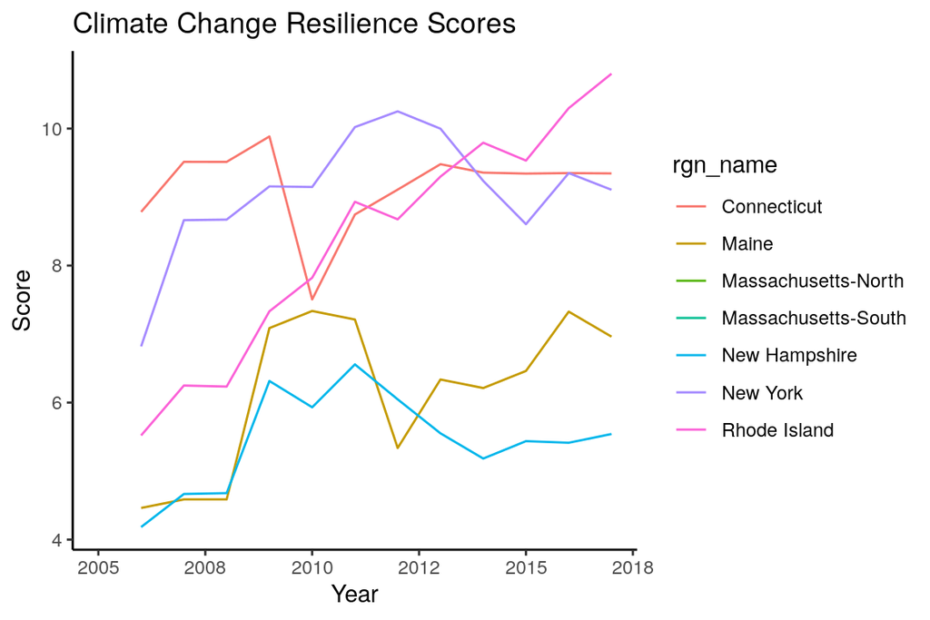

```r
cc_res_graph <- ggplot(cc_res_score)+
  geom_line(aes(x=year, y= score, color= rgn_name))+
 ggtitle("Climate Change Resilience Scores") +
  ylab("Score") +
  xlab("Year") +
  theme_classic()

cc_res_graph
```

```r
##save fig
ggsave("figs/cc_res_graph.jpg", width=7, height=5, dpi=300)
```

##Old code when using energy production to calculate if states are hitting their clean energy targets delete when done comparing the two

Calculate total energy production in each state each year

```r
raw_gen <- read_excel(file.path(dir_anx, "_raw_data/EIA/eia_annual_generation_state.xls"))

gen_total <- raw_gen %>%
  filter(year >= 2004 & year <=2017) %>%
  filter(state == "ME" | state == "NH" | state == "MA" | state == "RI" | state == "CT" | state == "NY") %>%
  filter(energy_source != "Total") %>%
  select(year, state, gen_mwh) %>%
  group_by(year, state) %>%
  dplyr::summarise(total_power = sum(gen_mwh)) %>%
  ungroup()
```

Calculate total clean/renewable energy production in each state each year

```r
gen_clean <- raw_gen %>%
  filter(year >= 2004 & year <=2017) %>%
  filter(state == "ME" | state == "NH" | state == "MA" | state == "RI" | state == "CT" | state == "NY") %>%
  filter(energy_source == "Hydroelectric Conventional"| energy_source == "Wind" | energy_source == "Solar Thermal and Photovoltaic" | energy_source == "Pumped Storage") %>%
  select(year, state, gen_mwh) %>%
  group_by(year, state) %>%
  dplyr::summarise(total_power_clean = sum(gen_mwh))%>%
  ungroup()
```

Combine data sets

```r
power_gen <- left_join(gen_total, gen_clean, by= c("year", "state")) %>%
  mutate(per_clean = total_power_clean/total_power)
```

Visualize percent of clean energy production

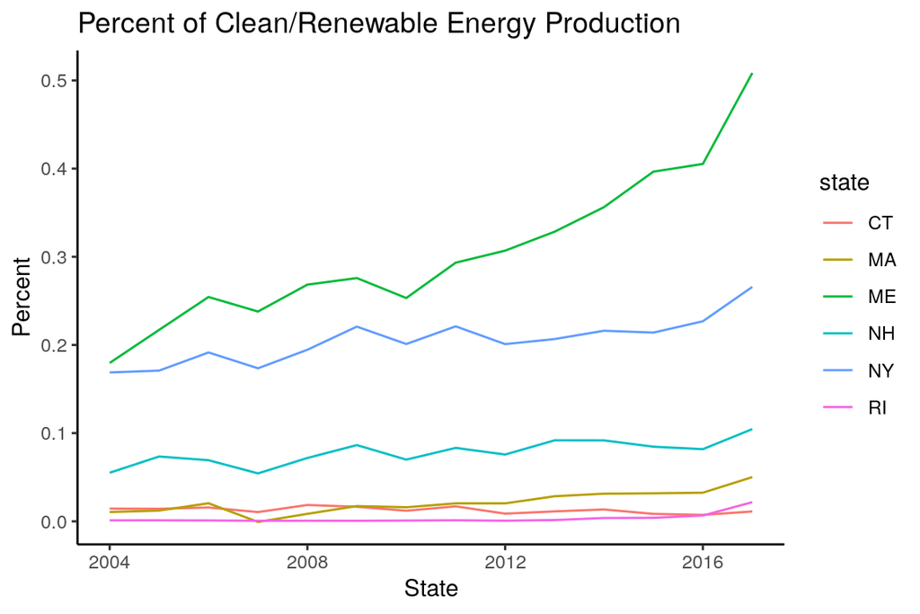

```r
graph_clean_pro <-ggplot(power_gen)+
  geom_line(aes(x=year, y = per_clean, color=state))+
  ggtitle("Percent of Clean/Renewable Energy Production") +
  ylab("Percent") +
  xlab("State") +
  theme_classic()
graph_clean_pro
```

```r
ggsave("figs/graph_clean_pro_nuclear.jpg", width=7, height=5, dpi=300)
```

Maine

```r
#MA 40% clean by 2017
me <- power_gen %>%
  filter(state == "ME") %>%
  mutate(year_n = seq(0:13))

#create tibble with the start (value in 2005) and end (goal in whichever year) to do a linear regression
me_target <- tribble(
  ~year, ~per_clean,
  0, 0.180,
  13, 0.4
)

#super simple regression for equation to calculate the necessary percent clean emmisions each year to reach target
lm_me <- lm(per_clean ~ year, data = me_target)
#intercept = 0.1800 ; coef =0.0169
summary(lm_me)
```

```
##
## Call:
## lm(formula = per_clean ~ year, data = me_target)
##
## Residuals:
## ALL 2 residuals are 0: no residual degrees of freedom!
##
## Coefficients:
##             Estimate Std. Error t value Pr(>|t|)
## (Intercept)   0.1800         NA      NA       NA
## year          0.0169         NA      NA       NA
##
## Residual standard error: NaN on 0 degrees of freedom
## Multiple R-squared:     1,   Adjusted R-squared:   NaN
## F-statistic:  NaN on 1 and 0 DF,  p-value: NA
```

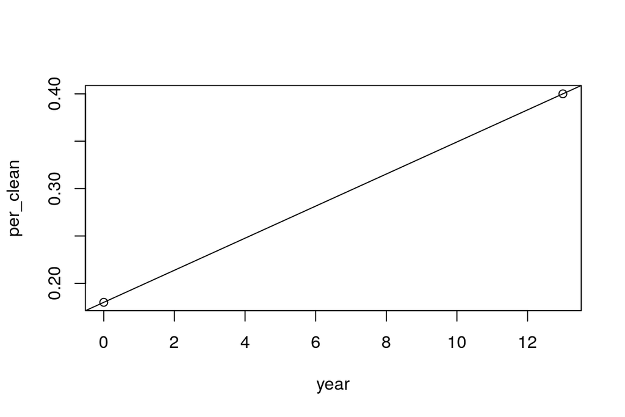

```r
plot(per_clean ~ year, data = me_target)
abline(lm_me)
```

```r
###trying to use equation no loop
me_clean_target <- me %>%
  rowwise() %>%
  mutate(target = (0.0169*year_n + 0.1800 ),
         per_clean = round(per_clean, digits= 2),
         target = round(target, digits= 2)) %>%
  filter( year != "2004") %>%
  select(year, state, per_clean, target)
```

Massachusets

```r
#MA 35% clean by 2030
ma <- power_gen %>%
  filter(state == "MA")  %>%
  mutate(year_n = seq(0:13),
         per_clean = if_else(per_clean <0, 0, per_clean))

#create tibble with the start (value in 2005) and end (goal in whichever year) to do a linear regression
ma_target <- tribble(
  ~year, ~per_clean,
  0, 0.0105 ,
  26, .35)

#super simple regression for equation to calculate the necessary percent clean emmisions each year to reach target
lm_ma <- lm(per_clean ~ year, data = ma_target)
#coef = 0.0131  ; int = 0.0105

ma_clean_target <- ma %>%
  rowwise() %>%
  mutate(target = (0.0131 *year_n+0.0105 ),
         per_clean = round(per_clean, digits= 2),
         target = round(target, digits= 2)) %>%
  filter( year != "2004") %>%
  select(year, state, per_clean, target)
```

New Hampshire

```r
#NH 25.2% clean by 2025
nh <- power_gen %>%
  filter(state == "NH") %>%
  mutate(year_n = seq(0:13))

#create tibble with the start (value in 2005) and end (goal in whichever year) to do a linear regression
nh_target <- tribble(
  ~year, ~per_clean,
  0, 0.0551,
  21, .252
)

#super simple regression for equation to calculate the necessary percent clean emmisions each year to reach target
lm_nh <- lm(per_clean ~ year, data = nh_target)
#coef=  0.00938 int= 0.05510

nh_clean_target <- nh %>%
  mutate(target = ( 0.00938*year_n +0.05510),
         per_clean = round(per_clean, digits= 2),
         target = round(target, digits= 2)) %>%
   filter( year != "2004") %>%
  select(year, state, per_clean, target)
```

Rhode Island

```r
#RI 38.5% clean by 2035
ri <- power_gen %>%
  filter(state == "RI") %>%
  mutate(year_n = seq(0:13))

#create tibble with the start (value in 2005) and end (goal in whichever year) to do a linear regression
ri_target <- tribble(
  ~year, ~per_clean,
  0, 0.001106   ,
  31, .385)

#super simple regression for equation to calculate the necessary percent clean emmisions each year to reach target
lm_ri <- lm(per_clean ~ year, data = ri_target)
#coef=0.01238  , int = 0.00111

ri_clean_target <- ri %>%
   mutate(target = ( 0.01238*year_n+0.00111),
         per_clean = round(per_clean, digits= 2),
         target = round(target, digits= 2)) %>%
  filter(year != "2004") %>%
  select(year, state, per_clean, target)
```

New York

```r
#NY 50% clean by 2030
ny <- power_gen %>%
  filter(state == "NY") %>%
  mutate(year_n = seq(0:13))

#create tibble with the start (value in 2005) and end (goal in whichever year) to do a linear regression
ny_target <- tribble(
  ~year, ~per_clean,
  0,    0.169   ,
  26, .50)

#super simple regression for equation to calculate the necessary percent clean emmisions each year to reach target
lm_ny <- lm(per_clean ~ year, data = ny_target)
#coef=0.0127   , int =  0.1690

ny_clean_target <- ny %>%
  mutate(target = (0.0127*year_n +0.1690 ),
         per_clean = round(per_clean, digits= 2),
         target = round(target, digits= 2)) %>%
  filter(year != "2004") %>%
  select(year, state, per_clean, target)
```

Connecticut

```r
#CT 44% clean by 2030
ct <- power_gen %>%
  filter(state == "CT")  %>%
  mutate(year_n = seq(0:13))

#create tibble with the start (value in 2005) and end (goal in whichever year) to do a linear regression
ct_target <- tribble(
  ~year, ~per_clean,
  0, 0.01441,
  26, .44
)

#super simple regression for equation to calculate the necessary percent clean emmisions each year to reach target
lm_ct <- lm(per_clean ~ year, data = ct_target)
#coef= 0.0164, int=0.0144

ct_clean_target <- ct %>%
  mutate(target = (0.0164*year_n +0.0144),
         per_clean = round(per_clean, digits= 2),
         target = round(target, digits= 2)) %>%
  filter(year != "2004") %>%
  select(year, state, per_clean, target)
```

Combine all states df with target

```r
energy_target <- rbind(me_clean_target, nh_clean_target, ma_clean_target, ri_clean_target, ct_clean_target, ny_clean_target)
```

Calculate scores

```r
power_gen_scores <- energy_target %>%
  mutate(score = per_clean/target,
         score = if_else(score >1, 1, score))
#save
write.csv(power_gen_scores, file = "data/power_gen_scores_nuc")
```

Visualize scores

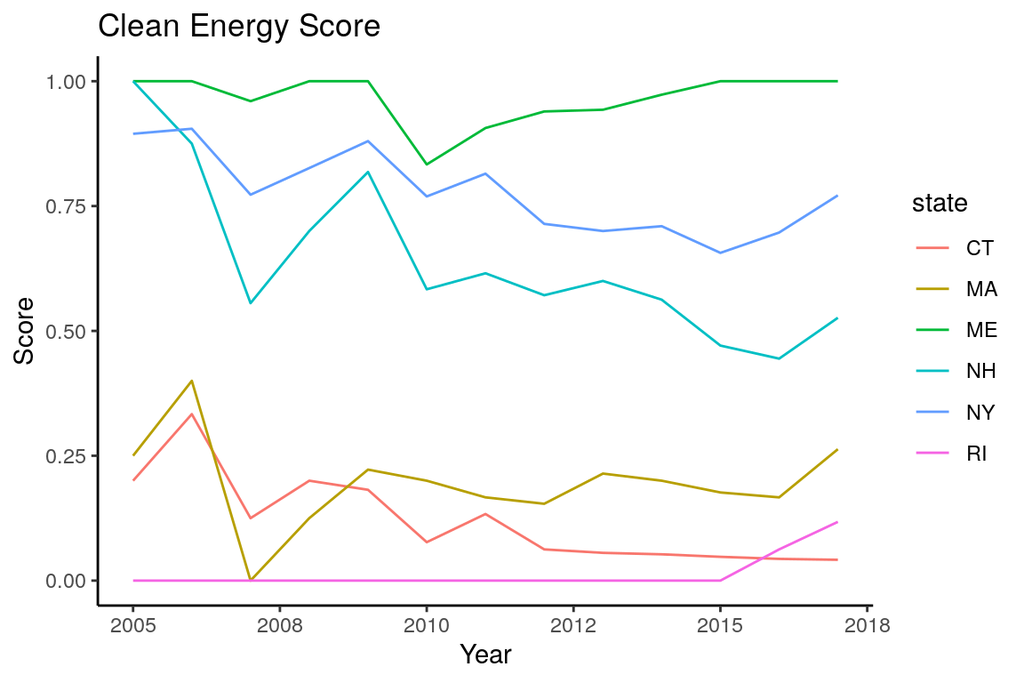

```r
graph_clean_energy_score_nuc <-ggplot(power_gen_scores)+
  geom_line(aes(x=year, y = score, color=state))+
  ggtitle("Clean Energy Score") +
  ylab("Score") +
  xlab("Year") +
  theme_classic()
graph_clean_energy_score_nuc
```

```r
ggsave("figs/graph_clean_generation_energy_score.jpg", width=7, height=5, dpi=300)
```